# Visualization alternatives

2023-05-29

## Introduction

In the original manuscript, we discussed the visualization. Here I provide some alternatives for the figures. Conclusion first: since the heterogeneity of the raw data is very high, maybe panel is still the best way, but I can add some auxiliary lines to the figure, so that readers can identify the key time point of the sub-figures.

## Change of annual indexes

Raw data in same figure, one color for one city:

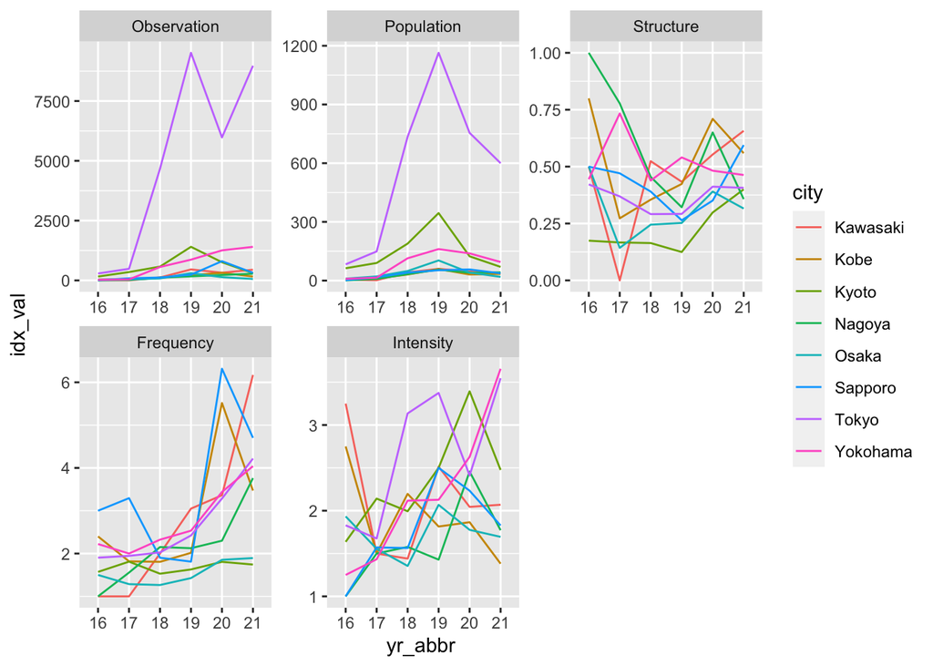

Since the data of Tokyo is much higher than that of the other cities, we can’t see the details of the other cities. Therefore, I scale the data by transfor the max value of a city into 1. Scaled data in same figure, one color for one city:

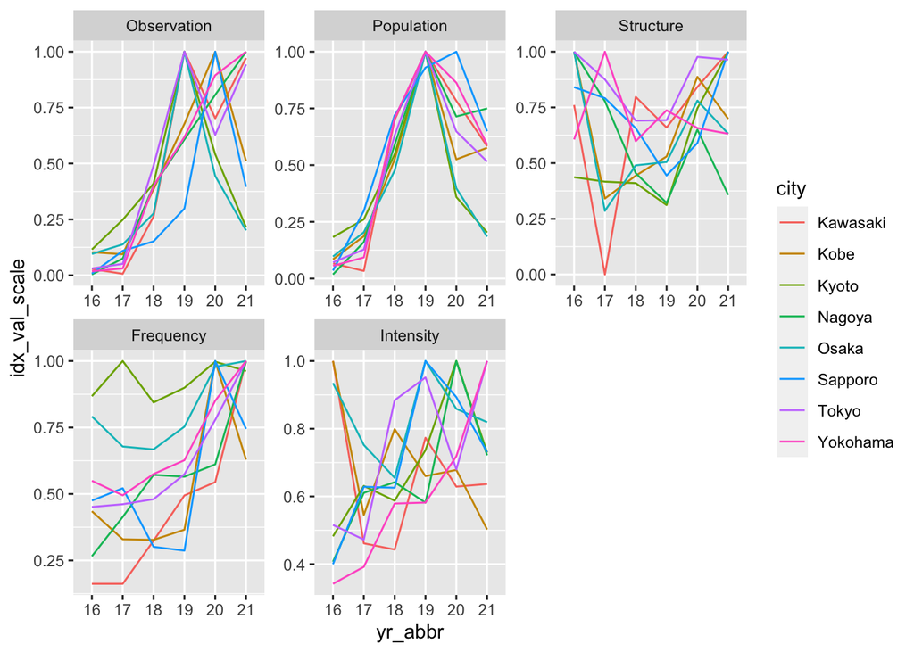

Still, it is chaos … so I think the original one (panle figure) is the best one.

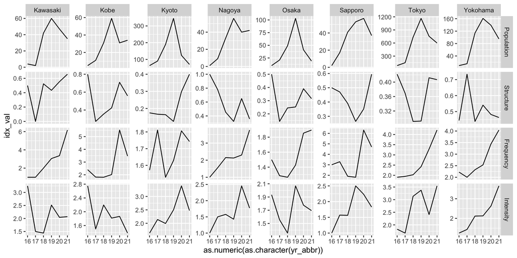

The problem of the panel figure is that it is difficult to identify if the cities change in a same way, for instance, if they all decrease since 2019. Therefore, I added a auxiliary line (showing year 2019) to each figure.

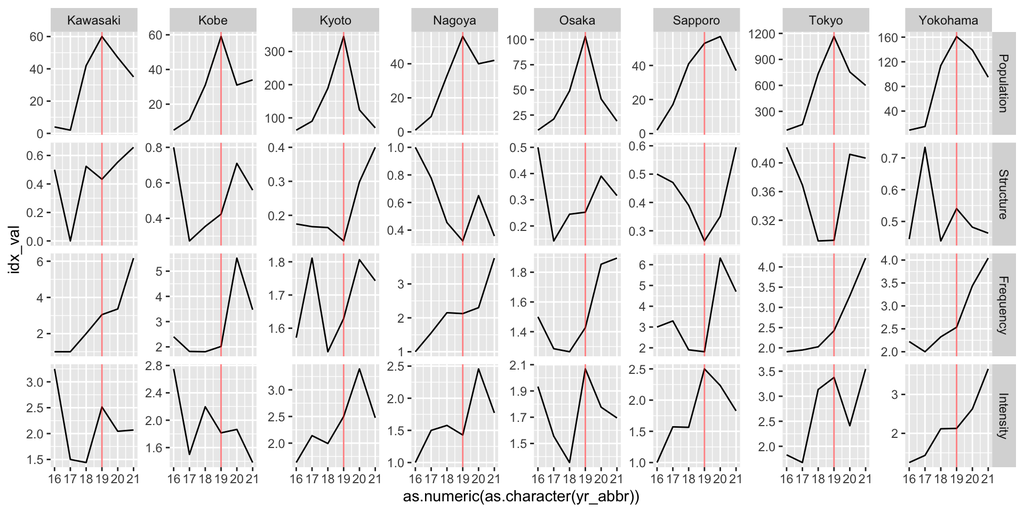

## LMDI result

For LMDI result, I also provide some alternatives.

The original one:

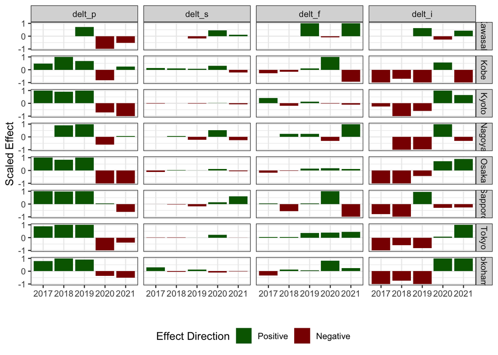

The line plot, which is usually applied in LMDI studies. We can do that either by effect:

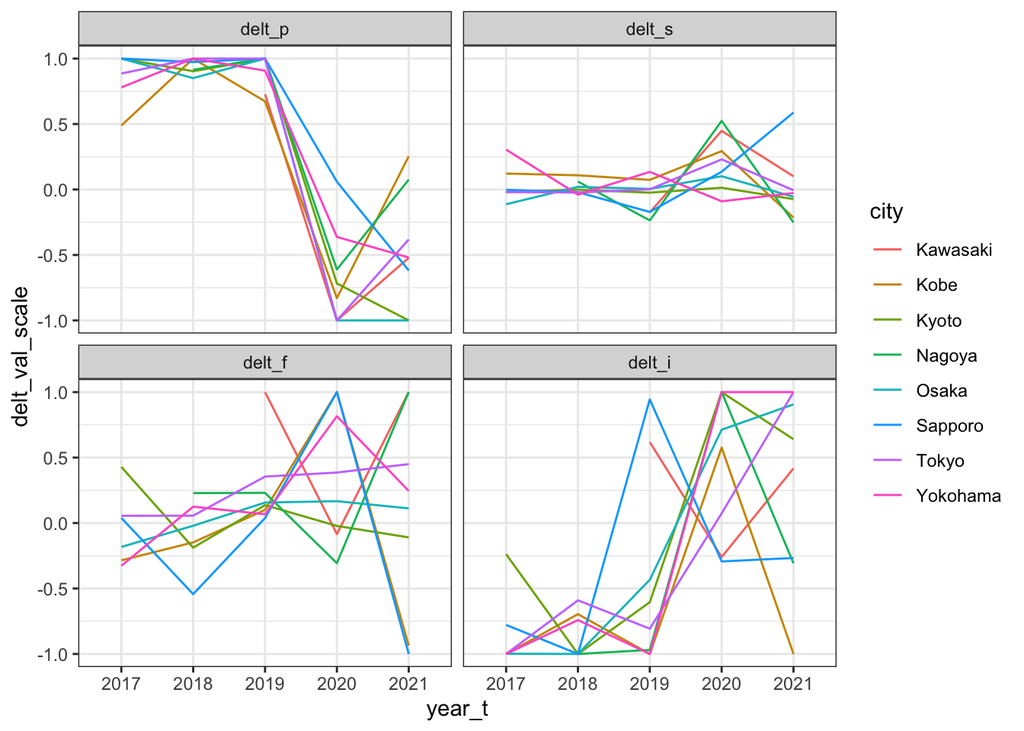

Or by cities:

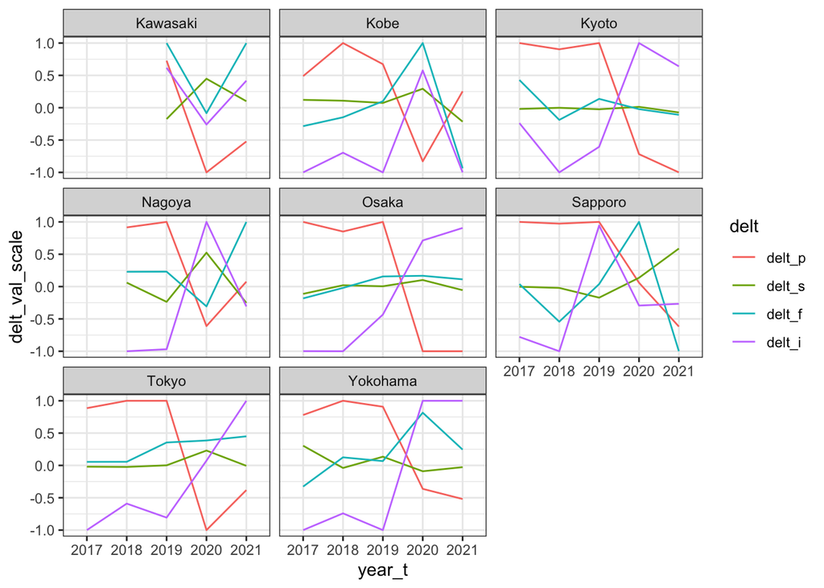

I think the best one is using tile plot:

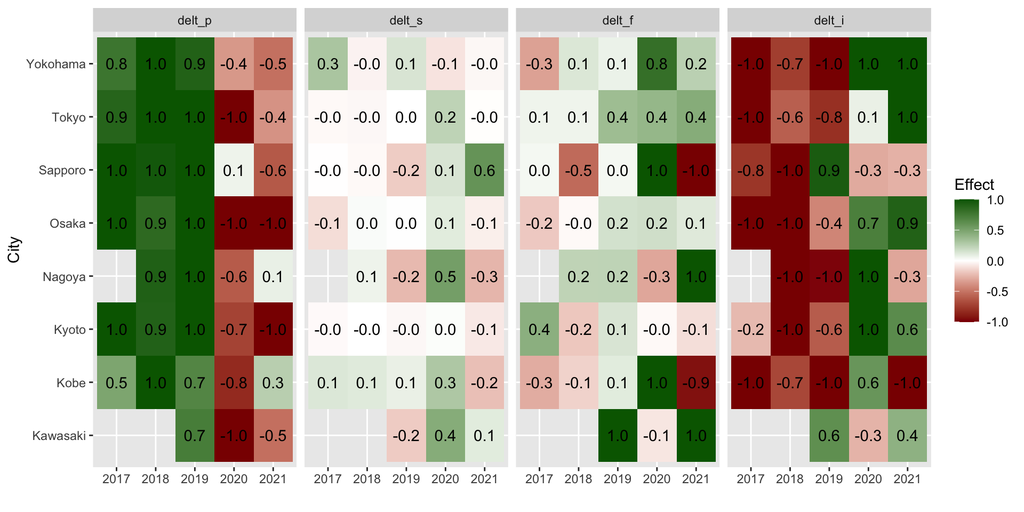